# **losmix**: Inference for Location-Scale Mixed-Effects Models

Martin Lysy

2021-01-13

## 1 Modeling Framework

Let $y_{it}$ and ${\boldsymbol{x}}_{it} = (x_{i1},\ldots,x_{ip})$ denote the response and variable and covariate vector of individual $i$ at time $t$. Let ${\boldsymbol{y}}_i = (y_{i1},\ldots,y_{iN_i})$ and ${\boldsymbol{X}}_i = ({\boldsymbol{x}}_{i1},\ldots,{\boldsymbol{x}}_{iN_i})$ denote the collection of $N_i$ measurements for individual $i$, and ${\boldsymbol{Y}}= ({\boldsymbol{y}}_{1},\ldots,{\boldsymbol{y}}_{M})$ and ${\boldsymbol{X}}= ({\boldsymbol{X}}_{1},\ldots,{\boldsymbol{X}}_{M})$, the collection of all measuments for the $M$ observed individuals.

The basic linear random-effects location-scale model we consider here is
$$\begin{equation}
\begin{aligned}
y_{it} & \stackrel{\mathrm{ind}}{\sim}\mathcal{N}({\boldsymbol{x}}_{it}'{\boldsymbol{\beta}}_i, \sigma_i^2) \\
({\boldsymbol{\beta}}_i, \sigma_i^2) & \stackrel{\mathrm{iid}}{\sim}\mathrm{mNIX}({\boldsymbol{\lambda}}, {\boldsymbol{\Omega}}, \nu, \tau),
\end{aligned}
\label{eq:hlr}
\end{equation}$$
where the multivariate normal-inverse-chi-square (mNIX) distribution is defined as
$$\begin{equation}
({\boldsymbol{\beta}}, \sigma^2) \stackrel{\mathrm{iid}}{\sim}\mathrm{mNIX}({\boldsymbol{\lambda}}, {\boldsymbol{\Omega}}, \nu, \tau) \qquad \iff \qquad
\begin{aligned}
\sigma^2 & \sim \mathrm{InvGamma}(\tfrac 1 2 \nu, \tfrac 1 2 \nu \tau) \\
{\boldsymbol{\beta}}\mid \sigma & \sim \mathcal{N}({\boldsymbol{\lambda}}, \sigma^2 {\boldsymbol{\Omega}}^{-1}).
\end{aligned}
\label{eq:mnix}
\end{equation}$$
The advantage of using the mNIX random-effects distribution \eqref{eq:mnix} is that it is the conjugate prior for ${\boldsymbol{\theta}}_i = ({\boldsymbol{\beta}}_i, \sigma_i^2)$:
$$\begin{equation*}
{\boldsymbol{\theta}}_i \mid {\boldsymbol{y}}, {\boldsymbol{X}}\stackrel{\mathrm{ind}}{\sim}\mathrm{mNIX}(\hat {\boldsymbol{\lambda}}_i, \hat {\boldsymbol{\Omega}}_i, \hat \nu_i, \hat \tau_i),
\end{equation*}$$
where
$$\begin{equation}
\begin{aligned}
\hat {\boldsymbol{\Omega}}_i & = {\boldsymbol{X}}_i'{\boldsymbol{X}}_i + {\boldsymbol{\Omega}}
&
\hat \nu_i & = N_i + \nu
\\
\hat {\boldsymbol{\lambda}}_i & = \hat {\boldsymbol{\Omega}}_i^{-1}({\boldsymbol{\Omega}}{\boldsymbol{\lambda}}+ {\boldsymbol{X}}_i'{\boldsymbol{y}}_i)
&
\hat \tau_i & = \hat \nu_i^{-1}\big({\boldsymbol{y}}_i'{\boldsymbol{y}}_i - \hat {\boldsymbol{\lambda}}_i \hat {\boldsymbol{\Omega}}_i \hat {\boldsymbol{\lambda}}_i + {\boldsymbol{\lambda}}'{\boldsymbol{\Omega}}{\boldsymbol{\lambda}}+ \nu\tau\big).
\end{aligned}
\label{eq:phihat}
\end{equation}$$
Moreover, the marginal likelihood of the hyperparameters ${\boldsymbol{\phi}}= ({\boldsymbol{\lambda}}, {\boldsymbol{\Omega}}, \nu, \tau)$ is available in closed form:
$$\begin{equation*}
\ell({\boldsymbol{\phi}}\mid {\boldsymbol{Y}}, {\boldsymbol{X}}) = - M \zeta({\boldsymbol{\phi}}) + \sum_{i=1}^M \zeta(\hat {\boldsymbol{\phi}}_i),
\end{equation*}$$
where
$$\begin{equation*}
\zeta({\boldsymbol{\phi}}) = \tfrac 1 2 \big[2\log \Gamma(\nu/2) - \log |{\boldsymbol{\Omega}}| - \nu \log(\nu\tau/2)\big],
\end{equation*}$$
and $\hat {\boldsymbol{\phi}}_i = (\hat {\boldsymbol{\lambda}}_i, \hat {\boldsymbol{\Omega}}_i, \hat \nu_i, \hat \tau_i)$ is given by \eqref{eq:phihat}.

### 1.1 Covariate-Free Case

A case of particular interest is when ${\boldsymbol{x}}_{it} \equiv 1$. In this case we typically relabel $\mu_i = \beta_{i1}$ and $\kappa = {\boldsymbol{\Omega}}_{1\times 1}$, and the mNIX distribution reduces to a normal-inverse-chi-square (NIX). That is, the random-effects distribution is $(\mu_i, \sigma_i^2) \stackrel{\mathrm{iid}}{\sim}\mathrm{NIX}(\lambda, \kappa, \nu, \tau)$, and the posterior distribution is also NIX with parameters
$$\begin{equation}
\begin{aligned}
\hat \kappa_i & = N_i + \kappa & \hat \nu_i & = N_i + \nu \\
\hat \lambda_i & = \hat \kappa_i^{-1}(\kappa\lambda + N_i \bar y_i) & \hat \tau_i & = \hat \nu_i^{-1}(\nu\tau + S_i + N_i\kappa/\hat \kappa_i(\bar y_i - \lambda)^2),
\end{aligned}
\label{eq:repostsimple}
\end{equation}$$
where $\bar y_i = \frac 1 {N_i} \sum_{t=1}^{N_i} y_{it}$ and $S_i = \sum_{t=1}^{N_i}(y_{it} - \bar y_i)^2$.

## 2 Bayesian Inference

Given a hyperparameter prior $\pi({\boldsymbol{\phi}})$, let $q({\boldsymbol{\phi}}\mid {\boldsymbol{Y}}, {\boldsymbol{X}}) = \ell({\boldsymbol{\phi}}\mid {\boldsymbol{Y}}, {\boldsymbol{X}}) + \log \pi({\boldsymbol{\phi}})$, and calculate
$$\begin{equation}
\hat {\boldsymbol{\phi}}= \operatorname{arg\,max}_{{\boldsymbol{\phi}}} q({\boldsymbol{\phi}}\mid {\boldsymbol{Y}}, {\boldsymbol{X}}), \qquad \hat {\boldsymbol{V}}= - \left[\frac{\partial^2}{\partial {\boldsymbol{\phi}}^2} q(\hat {\boldsymbol{\phi}}\mid {\boldsymbol{Y}}, {\boldsymbol{X}})\right]^{-1}.
\label{eq:hyperopt}
\end{equation}$$
Then for $M$ sufficiently large, the hyperparameter posterior distribution may be approximated as
$$\begin{equation*}
{\boldsymbol{\phi}}\mid {\boldsymbol{Y}}, {\boldsymbol{X}}\sim \mathcal{N}(\hat {\boldsymbol{\phi}}, \hat {\boldsymbol{V}}).
\end{equation*}$$

In order to estimate the random effect ${\boldsymbol{\theta}}_i = ({\boldsymbol{\beta}}_i, \sigma_i^2)$ for a given observation $i$, simulate iid draws ${\boldsymbol{\theta}}_i^{(1)}, \ldots, {\boldsymbol{\theta}}_i^{(B)}$ via
$$\begin{equation}
\begin{aligned}
{\boldsymbol{\phi}}^{(b)} & \stackrel{\mathrm{iid}}{\sim}\mathcal{N}(\hat {\boldsymbol{\phi}}, \hat {\boldsymbol{V}}) \\
{\boldsymbol{\theta}}_i^{(b)} \mid {\boldsymbol{\phi}}^{(b)} & \stackrel{\mathrm{ind}}{\sim}\mathrm{mNIX}(\hat {\boldsymbol{\lambda}}_i^{(b)}, \hat {\boldsymbol{\Omega}}_i^{(b)}, \hat \nu_i^{(b)}, \hat \tau_i^{(b)}),
\end{aligned}
\label{eq:repost}
\end{equation}$$
where $\hat {\boldsymbol{\phi}}_i^{(b)} = (\hat {\boldsymbol{\lambda}}_i^{(b)}, \hat {\boldsymbol{\Omega}}_i^{(b)}, \hat \nu_i^{(b)}, \hat \tau_i^{(b)})$ is calculated from \eqref{eq:phihat} using ${\boldsymbol{y}}_i$, ${\boldsymbol{X}}_i$, and ${\boldsymbol{\phi}}^{(b)}$. Then the $B$ draws from \eqref{eq:repost} are approximately iid draws from the random effects posterior distribution
$$\begin{equation*}
p({\boldsymbol{\theta}}_i \mid {\boldsymbol{Y}}, {\boldsymbol{X}}) = \int p({\boldsymbol{\theta}}_i \mid {\boldsymbol{y}}_i, {\boldsymbol{X}}_i, {\boldsymbol{\phi}}) p({\boldsymbol{\phi}}\mid {\boldsymbol{Y}}, {\boldsymbol{X}}) \mathrm{d}{\boldsymbol{\phi}}.
\end{equation*}$$

Thus, the crux of the computational challenge lies in the optimization problem \eqref{eq:hyperopt}. To do this, **losmix** uses the R package [**TMB**](https://CRAN.R-project.org/package=TMB) (Kristensen *et al.* 2016) to leverage the power of [automatic differentiation](https://en.wikipedia.org/wiki/Automatic_differentiation); both the (approximate) logposterior $q({\boldsymbol{\phi}}\mid {\boldsymbol{Y}}, {\boldsymbol{X}})$ and its gradient are computed in C++, thus allowing for very fast quasi-Newton optimization algorithms to calculate $\hat {\boldsymbol{\phi}}$.

### 2.1 Choice of Prior

In order to specify the hyperparameter prior $\pi({\boldsymbol{\phi}})$, we first switch to an unconstrained parametrization, namely
$$\begin{equation}
{\boldsymbol{\psi}}= ({\boldsymbol{\lambda}}, {\boldsymbol{\omega}}, \log \nu, \log \tau),
\label{eq:utrans}
\end{equation}$$
where ${\boldsymbol{\omega}}$ is a vector of length $p(p+1)/2$ corresponding to the upper Cholesky factor of ${\boldsymbol{\Omega}}_{p \times p}$ but with the log of its diagonal elements. In other words, if
$${\boldsymbol{U}}_{p\times p} = \begin{bmatrix}
\exp(\omega_1) & \omega_2 & \cdots & \omega_{p(p-1)/2 + 1} \\
0 & \exp(\omega_3) & \cdots & \omega_{p(p-1)/2 + 2} \\
\vdots & & \ddots & \vdots \\
0 & 0 & \cdots & \exp(\omega_{p(p-1)/2+p})
\end{bmatrix},$$
then ${\boldsymbol{U}}$ is the unique upper-triangular matrix with positive diagonal elements such that ${\boldsymbol{\Omega}}= {\boldsymbol{U}}'{\boldsymbol{U}}$.

A straightforward choice of default prior is the standard uninformative prior $\pi({\boldsymbol{\psi}}) \propto 1$. However, this prior is not invariant to permutation of the elements of ${\boldsymbol{\Omega}}$ corresponding to relabeling the elements of ${\boldsymbol{\beta}}$. In other words, if ${\boldsymbol{x}}_{it} = (\mathrm{gender}_i, \mathrm{age}_i)$ for subject $i$, then inference with the prior $\pi({\boldsymbol{\psi}}) \propto 1$ will be different if instead we had ${\boldsymbol{x}}_{it} = (\mathrm{age}_i, \mathrm{gender}_i)$. In order to avoid this, consider instead the prior
$$\begin{equation}
\pi({\boldsymbol{\psi}}) \propto \prod_{j=1}^p U_{jj}^{p-j},
\label{eq:scaleprior}
\end{equation}$$
where the $U_{jj}$ are easily obtained from ${\boldsymbol{\omega}}$. Then not only is Bayesian inference invariant to relabeling of ${\boldsymbol{x}}_{it}$, but in fact also to any transformation $\tilde {\boldsymbol{x}}_{it} = \boldsymbol{A} {\boldsymbol{x}}_{it}$ for invertible $\boldsymbol{A}_{p \times p}$.

With this choice of prior and unconstrained parametrization, the **TMB** optimization problem becomes finding
$$\begin{equation}
\hat {\boldsymbol{\psi}}= \operatorname{arg\,min}_{{\boldsymbol{\psi}}} r({\boldsymbol{\psi}}\mid {\boldsymbol{Y}}, {\boldsymbol{X}}), \qquad \hat {\boldsymbol{V}}= -\left[\frac{\partial^2}{\partial {\boldsymbol{\psi}}^2} r(\hat {\boldsymbol{\psi}}\mid {\boldsymbol{Y}}, {\boldsymbol{X}})\right]^{-1},
\label{eq:tmbopt}
\end{equation}$$
where $r({\boldsymbol{\psi}}\mid {\boldsymbol{Y}}, {\boldsymbol{X}}) = -\ell({\boldsymbol{\psi}}\mid {\boldsymbol{Y}}, {\boldsymbol{X}}) - \log \pi({\boldsymbol{\psi}})$ is the *negative* marginal log-posterior (the desired input for **TMB**).

## 3 Example

The following example provides a quick overview of the main **losmix** R functions:

- `mnix_sim()`: Generate random draws from an mNIX distribution.
- `mnix_marg()`: Create a `TMB::MakeADFun()` model object for the marginal hyperparameter posterior distribution (more on this momentarily).

### 3.1 Simulate Data

Let’s start by generating an arbitary dataset. Note the use of `mnix_sim()` to generate $({\boldsymbol{\beta}}_i, \sigma_i^2)$ from the mNIX distribution.

```r
require(losmix)

set.seed(1234) # reproducible results

p <- 3 # number of covariates
nSub <- 50 # number of subjects
N <- sample(20:50, nSub, replace = TRUE) # number of observations per subject

# hyperparameters
lambda <- rnorm(p)
Omega <- diag(p)
nu <- 5 * runif(1) + 3
tau <- rexp(1)

# parameters: generate them from an mNIX distribution
Theta <- mnix_sim(nSub, lambda = lambda, Omega = Omega, nu = nu, tau = tau)

# data: generate vector/matrix for each subject,
# then merge into single vector/matrix
# covariate matrices
X <- lapply(N, function(n) matrix(rnorm(n*p), n, p))
# response vectors
y <- lapply(1:nSub, function(ii) {
  rnorm(N[ii], mean = c(X[[ii]] %*% Theta$beta[ii,]), sd = Theta$sigma[ii])
})
# convert lists to single matrix/vector
X <- do.call(rbind, X)
y <- do.call(c, y)
# subject identifiers
id <- rep(1:nSub, times = N)
```

### 3.2 Marginal Posterior Inference

Now that we have simulated data, we can estimate the approximate marginal posterior distribution $p({\boldsymbol{\phi}}\mid {\boldsymbol{Y}}, {\boldsymbol{X}})$. To do this, we first use `TMB::MakeADFun()` to create a model object. This object contains, among other things, the *negative* log marginal posterior $r({\boldsymbol{\psi}}\mid {\boldsymbol{Y}}, {\boldsymbol{X}}) = -\log p({\boldsymbol{\psi}}\mid {\boldsymbol{Y}}, {\boldsymbol{X}})$ on the unconstrained scale \eqref{eq:utrans} with the scale-invariant prior \eqref{eq:scaleprior}, along with its gradient, ${\boldsymbol{g}}({\boldsymbol{\psi}}) = \frac{\partial}{\partial {\boldsymbol{\psi}}} r({\boldsymbol{\psi}}\mid {\boldsymbol{Y}}, {\boldsymbol{X}})$.

```r
# marginal posterior distribution
nlp <- mnix_marg(id = id, y = y, X = X)
names(nlp)
```

```
 [1] "par"      "fn"       "gr"       "he"       "hessian"  "method"
 [7] "retape"   "env"      "report"   "simulate"
```

To conduct the Bayesian inference scheme described in Section $2$, we proceed with the following steps:

1. Calculate $\hat {\boldsymbol{\psi}}$ and $\hat {\boldsymbol{V}}$ as defined in \eqref{eq:tmbopt}.
2. Simulate draws from the approximate posterior distribution

   $$\hat p({\boldsymbol{\psi}}\mid {\boldsymbol{Y}}, {\boldsymbol{X}}) \qquad \iff \qquad {\boldsymbol{\psi}}\mid {\boldsymbol{Y}}, {\boldsymbol{X}}\sim \mathcal{N}(\hat {\boldsymbol{\psi}}, \hat {\boldsymbol{V}}).$$
3. If we are interested in parameters on the original scale, then must apply the inverse transformation of \eqref{eq:utrans} to every sample obtained in Step 2.

In order to accomplish Step 1, R provides a couple of build-in functions for numerical optimization:

- `stats::optim()`: The default algorithm `method = "Nelder-Mead"` is derivative-free, but `method = "BFGS"` is a gradient-based quasi-Newton algorithm.
- `stats::nlm()`: This provides the option of including both gradient and hessian information. **TMB** can in fact use AD to compute the hessian ${\boldsymbol{H}}({\boldsymbol{\psi}}) = \frac{\partial^2}{\partial {\boldsymbol{\psi}}^2} r({\boldsymbol{\psi}}\mid {\boldsymbol{Y}}, {\boldsymbol{X}})$.
- `stats::nlminb()`: Another optimizer with optional gradient and hessian information.

Each of the algorithms above offers a different trade-off between speed, stability, and accuracy. As this trade-off is typically problem-dependent, **losmix** currently does not provide a default routine, but using any of the functions above is relatively straightforward. For high-dimensional optimization with large $p$, the user is invited to explore the [**nloptr**](https://CRAN.R-project.org/package=nloptr) suite of optimizers if the options above are insufficient.

The R code below using `stats::nlm()` to perform the optimization. Note the peculiar way in which function and gradient information are input simultaneously, instead of a separate arguments. This is to increase computational efficiency when function and gradient share certain calculations. This is the case for **TMB** functions, as calling `nlp$gr()` without arguments reuses calculations from the last call to `nlp$fn()`.

```r
# objective function
ofun <- function(par) {
  out <- nlp$fn(par)
  # include gradient information via 'attribute'
  attr(out, "gradient") <- nlp$gr()
  out
}

# optimization
opt <- nlm(p = nlp$par, # starting value (losmix picks a reasonable default)
           f = ofun) # objective function
opt$code # code == 1 means that 'nlm' thinks it converged
```

```
[1] 1
```

To check whether optimization was successful, the first thing is to check the built-in convergence diagnostic of `stat::nlm()`, in this case, `opt$code == 1` as above. Another check is the size of the gradient at the potential solution, on the absolute and relative scale:

```r
disp <- rbind(est = opt$estimate, # potential solution
              grad = opt$gradient, # gradient at the potential solution
              rel = opt$gradient/abs(opt$estimate)) # relative size
signif(disp, 2)
```

```
         [,1]     [,2]     [,3]    [,4]     [,5]     [,6]     [,7]    [,8]
est  -1.30000  7.0e-01 -1.00000 1.3e-01 -0.11000 -1.1e-02 -4.5e-02 -0.2200
grad  0.00019 -5.3e-05  0.00012 7.2e-05 -0.00029  3.4e-05  3.6e-05 -0.0005
rel   0.00014 -7.6e-05  0.00012 5.4e-04 -0.00260  3.1e-03  8.1e-04 -0.0023
         [,9]    [,10]    [,11]
est  -0.09200  2.4e+00 -6.1e-01
grad  0.00016 -8.5e-05  9.4e-05
rel   0.00170 -3.6e-05  1.5e-04
```

In this case the maximum gradient magnitude relative to the potential solution is 0.0030586, so we are reasonably confident to have arrived at a local minimum of $r({\boldsymbol{\psi}}\mid {\boldsymbol{Y}}, {\boldsymbol{X}})$. Thus we may use **TMB** to calculate $\hat {\boldsymbol{V}}= {\boldsymbol{H}}(\hat {\boldsymbol{\psi}}\mid {\boldsymbol{Y}}, {\boldsymbol{X}})^{-1}$ in order to complete Step 1. Note the use of `solveV()` to efficiently and stably compute the inverse of the symmetric positive-definite matrix ${\boldsymbol{H}}(\hat {\boldsymbol{\psi}}\mid {\boldsymbol{Y}}, {\boldsymbol{X}})$.

```r
psi_mean <- opt$estimate # (approximate) posterior mean of p(psi | Y, X)
psi_var <- solveV(nlp$he(opt$estimate)) # (approximate) posterior variance
```

Figure $1$ displays the approximate posterior distribution $\hat p(\phi_j \mid {\boldsymbol{Y}}, {\boldsymbol{X}})$ for each of hyperparameter on its original scale, after completing Steps 2 and 3.

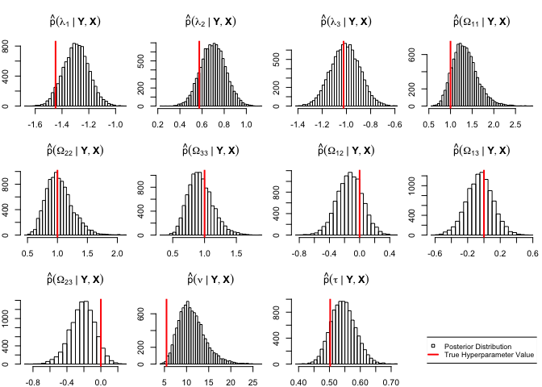

```r
# Step 2: sample from p_hat(psi | Y, X)

npost <- 1e4 # number of posterior draws
Psi_post <- rmvn(n = npost, mu = psi_mean, Sigma = psi_var)

# Step 3: convert to sample from p_hat(phi | Y, X)
Phi_post <- ivec_phi(Psi_post)

# histograms of posterior distributions
# true hyperparameter values are vertical lines in red

# format data for plotting
iOmega <- cbind(rbind(1:p, 1:p), combn(1:p,2)) # unique elements of Omega
Phi_plot <- cbind(Phi_post$lambda, # lambda
                  apply(iOmega, 2,
                        function(ii) Phi_post$Omega[ii[1],ii[2],]), # Omega
                  Phi_post$nu, # nu
                  Phi_post$tau) # tau
# hyperparameter names
phi_names <- c(paste0("lambda[", 1:p, "]"),
               paste0("Omega[", iOmega[1,], iOmega[2,], "]"),
               "nu", "tau")
# true values
phi_true <- c(lambda, Omega[t(iOmega)], nu, tau)

# create plot
par(mfrow = c(3,4), mar = c(2,2,4,.5))
for(ii in 1:ncol(Phi_plot)) {
  # approximate posterior
  hist(Phi_plot[,ii], breaks = 40, xlab = "", ylab = "",
       main = parse(text = paste0("hat(p)(", phi_names[ii],
                                  "*\" | \"*bold(Y),bold(X))")))
  # true parameter value
  abline(v = phi_true[ii], col = "red", lwd = 2)
}
# legend
plot(0, type = "n", xlim = c(0,1), ylim = c(0,1),
     xlab = "", ylab = "", axes = FALSE)
legend("bottom", inset = .05,
       legend = c("Posterior Distribution", "True Hyperparameter Value"),
       lwd = c(NA, 2), pch = c(22, NA), seg.len = 1.5,
       col = c("black", "red"), bg = c("white", NA), cex = .85)
```

Figure 1: Approximate posterior distribution for each hyperparameter on the original scale.

### 3.3 Inference for Random Effects

The following R code shows how to estimate the random effects ${\boldsymbol{\theta}}_i = ({\boldsymbol{\beta}}_i, \sigma_i^2)$ for an individual $i$ using the approximate posterior distribution \eqref{eq:repost}. The approximate posterior $\hat p({\boldsymbol{\theta}}_i \mid {\boldsymbol{Y}}, {\boldsymbol{X}})$ and the true parameter value are shown in Figure $2$.

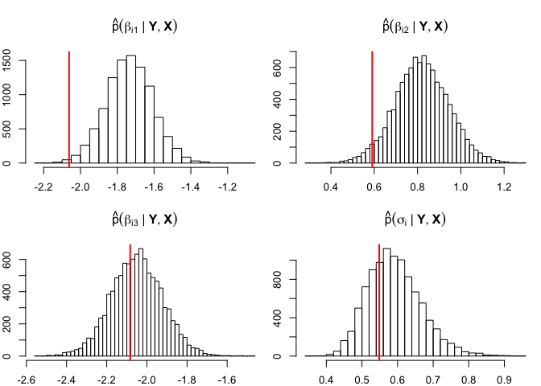

```r
# inference for random effects

iSub <- sample(nSub, 1) # pick a subject at random

# data for subject i
Xi <- X[id == iSub,]
yi <- y[id == iSub]

# sample from p(thetai | y, X)
Thetai_post <- mnix_sim(npost,
                        lambda = Phi_post$lambda, Omega = Phi_post$Omega,
                        nu = Phi_post$nu, tau = Phi_post$tau,
                        y = yi, X = Xi)

# plot (approximate) posterior distributions
# true parameter values are plotted in red

# format data for plotting
Thetai_plot <- cbind(Thetai_post$beta, # beta
                     Thetai_post$sigma) # sigma
# parameter names
thetai_names <- c(paste0("beta[i", 1:p, "]"), "sigma[i]")
# true parameter values for subject i
thetai_true <- c(Theta$beta[iSub,], sigma = Theta$sigma[iSub])

# create plot
par(mfrow = c(2,2), mar = c(2,2,4,.5))
for(ii in 1:ncol(Thetai_plot)) {
  # approximate posterior
  hist(Thetai_plot[,ii], breaks = 40, xlab = "", ylab = "",
       main = parse(text = paste0("hat(p)(", thetai_names[ii],
                                  "*\" | \"*bold(Y),bold(X))")))
  # true parameter value
  abline(v = thetai_true[ii], col = "red", lwd = 2)
}
```

Figure 2: Approximate posterior distribution for the random effects of a given subject $i$.

## 4 Model Extensions

Model \eqref{eq:hlr} can easily be extended by letting ${\boldsymbol{X}}= {\boldsymbol{X}}({\boldsymbol{\eta}})$ and ${\boldsymbol{\phi}}= {\boldsymbol{\phi}}({\boldsymbol{\eta}})$ each depend on hyperparameters ${\boldsymbol{\eta}}$. For example, consider the model
$$\begin{equation}
\begin{aligned}
y_{it} & \stackrel{\mathrm{ind}}{\sim}\mathcal{N}(\beta_{i1} + \beta_{i2} \exp(-\gamma t), \sigma_i^2) \\
({\boldsymbol{\beta}}_i, \sigma_i^2) & \stackrel{\mathrm{ind}}{\sim}\mathrm{mNIX}({\boldsymbol{\lambda}}, {\boldsymbol{\Omega}}, \nu \cdot x_i, \tau),
\end{aligned}
\label{eq:hlrex}
\end{equation}$$
such that covariates of the model are $x_{it} = (t, x_i)$ and the hyperparameters are ${\boldsymbol{\eta}}= (\gamma, {\boldsymbol{\lambda}}, {\boldsymbol{\Omega}}, \nu, \tau)$.

Model \eqref{eq:hlrex} is implemented in C++ using **TMB** interface to R, along with the **losmix** C++ library in the code block below. The code can also be found in the file `ModelExt.cpp` located in the directory returned by the following call:

```r
system.file("include", "losmix", "ModelExt.cpp", package = "losmix")
```

A couple of useful resources for following the C++ code:

- **TMB** is extensively documented [here](https://github.com/kaskr/adcomp/wiki/Documentation).
- **TMB** uses the [**Eigen**](http://eigen.tuxfamily.org/index.php?title=Main_Page) C++ library for linear algebra (i.e., matrix operations), which is extensively documented [here](http://eigen.tuxfamily.org/dox/).

```cpp
#include <TMB.hpp> // _must_ put this first
// include losmix library
#include "losmix/utils.hpp"
#include "losmix/mNIX.hpp"

template<class Type>
Type objective_function<Type>::operator() () {
  using namespace losmix;
  // --- INPUT VARIABLES ---
  // data input: output of the call losmix::format_data
  DATA_MATRIX(y); // response vector y (as a matrix)
  DATA_MATRIX(Xtr); // _transpose_ of covariate matrix X
  DATA_IVECTOR(iStart); // start of each subject
  DATA_IVECTOR(nObs); // number of observations per subject
  // parameter input (order is arbitrary)
  PARAMETER(gamma);
  PARAMETER_VECTOR(lambda);
  PARAMETER_VECTOR(logC_Omega); // cholesky factor of Omega
  PARAMETER(log_nu);
  PARAMETER(log_tau);

  // --- INTERMEDIATE VARIABLES ---
  int nSub = nObs.size(); // number of subjects
  int p = lambda.size(); // number of regression coefficients
  // hyperparameter conversions of Omega, nu, tau
  matrix<Type> Omega(p,p);
  // lchol2var expects one-column matrix as second input
  utils<Type>::lchol2var(Omega, logC_Omega.matrix());
  Type nu = exp(log_nu);
  Type tau = exp(log_tau);
  matrix<Type> XtrGamma(p, Xtr.cols()); // hyperparameter-dependent covariate matrix
  XtrGamma.row(0).setOnes();
  XtrGamma.row(1) = (-gamma * Xtr.row(0)).array().exp();
  Type nuX; // covariate-dependent degrees-of-freedom
  mNIX<Type> mnix(p); // mNIX distribution object

  // --- OUTPUT VARIABLES ---
  Type mll = 0; // marginal log-likelihood
  // random effects variables
  matrix<Type> beta(p, nSub); // regression coefficients
  vector<Type> sigma(nSub); // error standard deviations

  // --- CALCULATIONS ---
  for(int ii=0; ii<nSub; ii++) {
    nuX = nu * Xtr(1,iStart(ii)); // covariate-dependent degrees of freedom
    // posterior calculations
    mnix.set_prior(lambda, Omega, nuX, tau);
    mnix.set_suff(y.block(iStart[ii],0,nObs[ii],1),
          XtrGamma.block(0,iStart[ii],p,nObs[ii]));
    mnix.calc_post();
    mll += mnix.log_marg(); // increment marginal likelihood
    SIMULATE {
      // simulate random effect for each subject
      // enclose in SIMULATE block to avoid AD derivative calculations,
      // i.e., faster
      mnix.simulate(beta.col(ii), sigma(ii));
    }
  }
  // hyperparameter prior
  // the default prior on unconstrained scalars is "uniform(-Inf,Inf)"
  // the default prior on the log-Cholesky decomposition of a variance matrix
  // is the 'lchol_prior' below.
  mll += utils<Type>::lchol_prior(logC_Omega);
  // return random effects
  SIMULATE {
    REPORT(beta);
    REPORT(sigma);
  }
  return -mll; // TMB expects a _negative_ log marginal posterior
}
```

### 4.1 Compiling and Testing

`ModelExt.cpp` is compiled in an R session as follows:

```r
require(TMB)

model_name <- "ModelExt"
# instruct TMB where to find losmix library
include_path <- system.file("include", package = "losmix")
# compile and load model
TMB::compile(paste0(model_name, ".cpp"),
             PKG_CXXFLAGS = paste0('-I"', include_path, '"'))
dyn.load(TMB::dynlib(model_name))
```

The following R code shows how to conduct approximate Bayesian inference for model \eqref{eq:hlrex} by testing that the C++ implementation is correct. So first let’s simulate some data from model \eqref{eq:hlrex}:

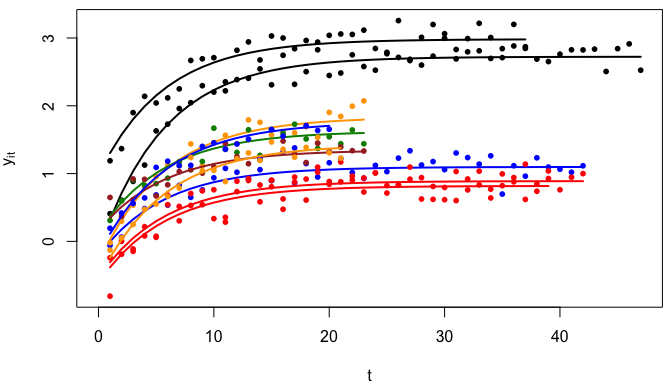

```r
nSub <- 10 # number of subjects
N <- sample(20:50, nSub, replace = TRUE) # observations per subject

# hyperparameters
gamma <- runif(1) * .2
lambda <- rnorm(2)
Omega <- crossprod(matrix(rnorm(4), 2, 2))/10
nu <- runif(1, 1, 2)*50
tau <- rexp(1)/100

# covariates
X <- lapply(N, function(N) {
  cbind(t = 1:N, x = runif(1, 1, 5))
})

# parameters
Theta <- mnix_sim(nSub, lambda = lambda, Omega =  Omega,
                  nu = nu * sapply(X, function(x) x[1,2]), tau = tau)

# responses
# mean vectors
Mu <- lapply(1:nSub, function(ii) {
  Theta$beta[ii,1] + Theta$beta[ii,2] * exp(-gamma * X[[ii]][,1])
})
# observation vectors
y <- lapply(1:nSub, function(ii) {
  rnorm(N[ii], mean = Mu[[ii]], sd = Theta$sigma[ii])
})
# convert data to regular format
X <- do.call(rbind, X)
y <- do.call(c, y)
id <- rep(1:nSub, times = N)

# plot data
par(mfrow = c(1,1), mar = c(4,4,.5,.5))
clrs <- rep(c("black", "blue", "red", "orange", "green4", "brown"),
            len = nSub)
plot(0, type = "n", ylab = expression(y[it]), xlab = expression(t),
     xlim = c(0, max(N)), ylim = range(sapply(Mu, range), y))
invisible(sapply(1:nSub, function(ii) {
  lines(x = 1:N[ii], y = Mu[[ii]], col = clrs[ii], lwd = 2)
  points(x = 1:N[ii], y = y[id == ii], pch = 16, cex = .8, col = clrs[ii])
}))
```

Figure 3: Mean and actual response (solid line and points) as a function of $t$ for each subject $i$.

Now, let’s implement the (negative) marginal log-posterior $r({\boldsymbol{\psi}}\mid {\boldsymbol{Y}}, {\boldsymbol{X}})$ in R and check that it returns exactly the same value as `ModelExt.cpp`. First a few helper functions:

```r
# simulate hyperparameters on the transformed scale
sim_psi <- function() {
  gamma <- runif(1)
  lambda <- rnorm(2)
  Omega <- crossprod(matrix(rnorm(4), 2, 2))
  nu <- runif(1, 1, 2)
  tau <- rexp(1)/5
  list(gamma = gamma, lambda = lambda,
       logC_Omega = log_chol(Omega),
       log_nu = log(nu), log_tau = log(tau))
}
# _negative_ marginal log-posterior for ModelExt:
# R implementation
mxt_r <- function(psi, id, y, X) {
  nSub <- length(unique(id))
  lm <- sapply(1:nSub, function(ii) {
    # individual covariate and responses
    Xi <- X[id == ii,]
    yi <- y[id == ii]
    # hyperparameters on the regular scale
    gamma <- psi$gamma
    lambda <- psi$lambda
    Omega <- ilog_chol(psi$logC_Omega)
    nu <- exp(psi$log_nu) * Xi[1,2] # covariate-dependent
    tau <- exp(psi$log_tau)
    # covariate matrix
    Xi <- cbind(1, exp(-gamma * Xi[,1])) # hyperparameter-dependent
    # posterior mNIX hyperparameters
    phi_post <- mnix_post(y = yi, X = Xi,
                          lambda = lambda, Omega = Omega, nu = nu, tau = tau)
    # marginal likelihood per individual
    mnix_zeta(Omega = phi_post$Omega, nu = phi_post$nu, tau = phi_post$tau) -
      mnix_zeta(Omega = Omega, nu = nu, tau = tau)
  })
  # default prior
  lpi <- lchol_prior(ilog_chol(psi$logC_Omega))
  -(sum(lm) + lpi) # negative loglikelihood
}
```

Here’s how to create an instance of the **TMB** (negative) marginal log-posterior:

```r
# _negative marginal logposterior for ModelExt:
# TMB implementation
mxt_data <- format_data(id = id, y = y, X = X) # TMB format
mxt_pars <- sim_psi() # initialize with arbitrary values (placeholders)
mxt_tmb <- TMB::MakeADFun(data = mxt_data,
                          parameters = mxt_pars,
                          DLL = model_name, silent = TRUE)
```

Now let’s check that the R and **TMB** implementations return exactly the same results:

```r
replicate(10, expr = {
  psi <- sim_psi()
  mxt_r(psi = psi, id = id, y = y, X = X) - mxt_tmb$fn(unlist(psi))
})
```

```
 [1] -2.273737e-13 -1.136868e-12 -4.263256e-13 -4.973799e-14 -2.966516e-13
 [6] -2.673417e-13 -2.380318e-13 -1.207923e-13 -1.012523e-13 -3.304024e-13
```

And finally, we can sample from $\hat p({\boldsymbol{\psi}}\mid {\boldsymbol{Y}}, {\boldsymbol{X}})$ as before:

```r
# objective function
ofun <- function(par) {
  out <- mxt_tmb$fn(par)
  attr(out, "gradient") <- mxt_tmb$gr()
  out
}

# optimization
opt <- nlm(p = mxt_tmb$par, f = ofun)
opt$code # code == 1 means that 'nlm' thinks it converged
```

```
[1] 1
```

```r
# approximate posterior inference
npost <- 1e4 # number of posterior draws
psi_mean <- opt$estimate # (approximate) posterior mean
psi_var <- solveV(mxt_tmb$he(opt$estimate)) # (approximate) posterior variance
Psi_post <- rmvn(n = npost, mu = psi_mean, Sigma = psi_var)
```

### 4.2 Inference for Random Effects

For simplicity, the simulation of random effects suggested here is slightly different than for the build-in model `mnix_marg` using `mnix_suff`. That is, the **TMB** model has been set up such that

```r
mxt_tmb$simulate(psi)
```

will return one draw from $p({\boldsymbol{\theta}}_i \mid {\boldsymbol{y}}_i, {\boldsymbol{X}}_i, {\boldsymbol{\psi}})$ for each subject $i$. Therefore, the following R code produces samples from the approximate random effects distribution $\hat p({\boldsymbol{\theta}}_i \mid {\boldsymbol{Y}}, {\boldsymbol{X}})$ \eqref{eq:repost}:

```r
iSub <- sample(nSub, 1) # pick an observation at random
# TMB implementation for a single subject
mxt1_data <- format_data(y = y[id == iSub], X = X[id == iSub,]) # TMB format
mxt1_tmb <- TMB::MakeADFun(data = mxt1_data,
                           parameters = sim_psi(), # placeholder
                           DLL = model_name, silent = TRUE)
```

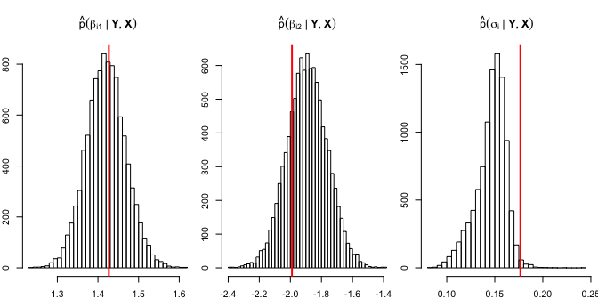

```r
# simulate from random-effects distribution
# note: there is no need to convert to original parametrization first
Thetai_post <- apply(Psi_post, 1, function(psi) mxt1_tmb$simulate(psi))
# convert from list of lists to list with beta and sigma
Thetai_post <- unlist_bind(Thetai_post,
                           name = c("beta", "sigma"), bind = c(cbind, c))
Thetai_post$beta <- t(Thetai_post$beta) # beta needs to be transposed
thetai_true <- c(Theta$beta[iSub,], Theta$sigma[iSub]) # true parameter values

# plot
Thetai_plot <- cbind(Thetai_post$beta, Thetai_post$sigma)
thetai_names <- c("beta[i1]", "beta[i2]", "sigma[i]")
par(mfrow = c(1,3), mar = c(2,2,4,.5))
for(ii in 1:ncol(Thetai_plot)) {
  # approximate posterior
  hist(Thetai_plot[,ii], breaks = 40, xlab = "", ylab = "",
       main = parse(text = paste0("hat(p)(", thetai_names[ii],
                                  "*\" | \"*bold(Y),bold(X))")))
  # true parameter value
  abline(v = thetai_true[ii], col = "red", lwd = 2)
}
```

Figure 4: Approximate posterior distribution for the random effects of a given subject $i$.

## 5 References

Kristensen, K., Nielsen, A., Berg, C.W., Skaug, H., and Bell, B.M., 2016. TMB: Automatic differentiation and Laplace approximation. *Journal of Statistical Software*, 70 (5), 1–21.